# Homework 3

Author

Allison Louie

```r
library(data.table)
library(dplyr)
library(tidytext)
library(stringr)
library(tidyverse)
library(ggplot2)
pubmed <- read.csv("https://raw.githubusercontent.com/USCbiostats/data-science-data/master/03_pubmed/pubmed.csv")
```

## 1. Tokenize the abstracts and count the number of each token. Do you see anything interesting? Does removing stop words change what tokens appear as the most frequent? What are the 5 most common tokens for each search term after removing stopwords?

```r
data_tokens <- pubmed %>%
  unnest_tokens(token, abstract)%>%
  count(token, sort = TRUE)
data_tokens
```

```
                             token     n
1                              the 28126
2                               of 24760
3                              and 19993
4                               in 14653
5                               to 10920
6                                a  8245
7                             with  8038
8                            covid  7275
9                               19  7080
10                              is  5649
11                             for  5492
12                        patients  4674
13                          cancer  3999
14                        prostate  3832
```

[output cut: 20553 more lines]

Most of it has to do with filler words like the, of, and, in, to, a, with, and is. We need to remove these words to see if there are actual content to be observed.

```r
token <- data_tokens[!data_tokens$token %in% stop_words, ]
top_5_tokens <- head(token, 5)
top_5_tokens
```

```
  token     n
1   the 28126
2    of 24760
3   and 19993
4    in 14653
5    to 10920
```

## 2. Tokenize the abstracts into bigrams. Find the 10 most common bigrams and visualize them with ggplot2.

```r
bigrams <- pubmed %>%
  unnest_tokens(bigram, abstract, token = "ngrams", n = 2)
bigram_counts <- bigrams %>%
  count(bigram, sort = TRUE)
top_10_bigrams <- bigram_counts %>%
  top_n(10, n)
top_10_bigrams
```

```
            bigram    n
1         covid 19 6969
2           of the 3883
3           in the 3418
4  prostate cancer 3222
5    pre eclampsia 1854
6    patients with 1587
7         of covid 1519
8          and the 1154
9           to the 1061
10     of prostate  870
```

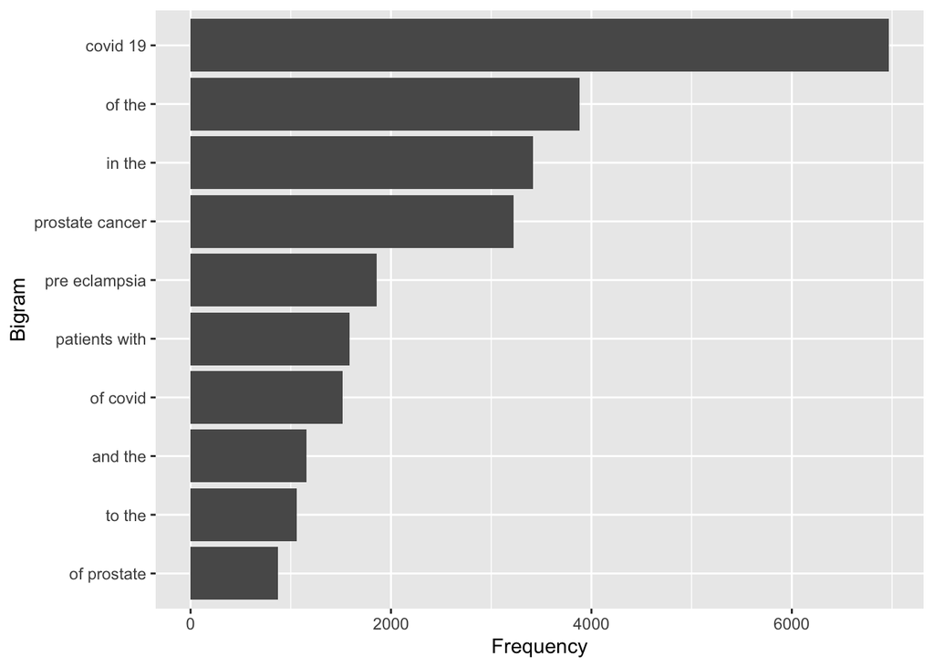

```r
ggplot(top_10_bigrams, aes(n, reorder(bigram, n))) +
  geom_col() +
  labs(x = "Frequency", y = "Bigram")
```

A lot of them still have filler words like of the, in the, patients with, and the, to the, and of prostate. It is not very specific, but we know that these phrases have been utilized a lot.

## 3. Calculate the TF-IDF value for each word-search term combination (here you want the search term to be the “document”). What are the 5 tokens from each search term with the highest TF-IDF value? How are the results different from the answers you got in question 1?

```r
pubmed%>%
  unnest_tokens(text, abstract)%>%
  count(text, term)%>%
  bind_tf_idf(text, term, n)%>%
  arrange(desc(tf_idf))%>%
  group_by(term)%>%
  slice(1:5)
```

```
# A tibble: 25 × 6
# Groups:   term [5]
   text        term                n      tf   idf  tf_idf
   <chr>       <chr>           <int>   <dbl> <dbl>   <dbl>
 1 covid       covid            7275 0.0371  1.61  0.0597
 2 pandemic    covid             800 0.00408 1.61  0.00657
 3 coronavirus covid             647 0.00330 1.61  0.00531
 4 sars        covid             372 0.00190 1.61  0.00305
 5 cov         covid             334 0.00170 1.61  0.00274
 6 cf          cystic fibrosis   625 0.0127  0.916 0.0117
 7 fibrosis    cystic fibrosis   867 0.0176  0.511 0.00901
 8 cystic      cystic fibrosis   862 0.0175  0.511 0.00896
 9 cftr        cystic fibrosis    86 0.00175 1.61  0.00282
10 sweat       cystic fibrosis    83 0.00169 1.61  0.00272
# ℹ 15 more rows
```

In this, we see the amount of times certain words appear with certain terms, seeing how it often appears. Also, it doesn’t have stop words in this, being more specific with what appears with each term. We get a better understanding of what is going on and being associated with each term.